# Interval Estimation

Carter Allen

10/2/2018

## Sampling Distributions

Fundamental to the idea of interval estimation is the sampling distribution of a statistic. As you have learned, a statistic (remember the term statistic is simply defined as a mathematical function of data) computed from data arising from a given distribution has its own distribution. The probability distribution of a statistic is called a *sampling distribution*. We have learned a few important theorems that inform us of the sampling distribution of common statistics.

*Theorem 1*: Let $X_1, X_2, ..., X_n$ be a sample of size $n$ from a Normal population with mean $\mu$ and variance $\sigma^2$. Assume $\sigma^2$ is known. Define $\bar{X} = \frac{\sum_{i = 1}^n X_i}{n}$ as the sample mean of the $n$ observations. The sampling distribution of $\bar{X}$ is as follows.

$$\bar{X} \sim N(\mu, \frac{\sigma^2}{n})$$

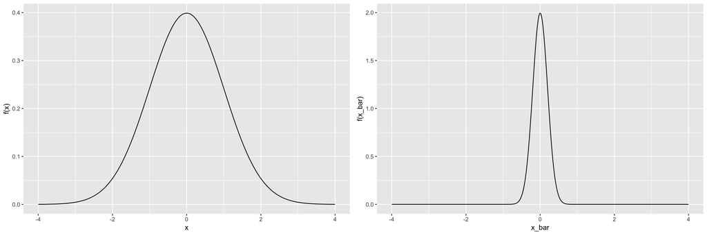

*Theorem 2*: Let $X_1, X_2, ..., X_n$ be a sample of size $n$ from a Normal population with mean $\mu$ and variance $\sigma^2$. Assume $\sigma^2$ is unknown. Define $\bar{X} = \frac{\sum_{i = 1}^n X_i}{n}$ as the sample mean of the $n$ observations, and $S^2 = \frac{\sum_{i = 1}^n (X_i-\bar{X})^2}{n-1}$ as the unbiased estimate of the true population variance. The sampling distribution of $\bar{X}$ is as follows.

$$\frac{\bar{X}-\mu}{S/\sqrt{n}} \sim t_{df = n-1}$$

*Theorem 3*: Let $X_1, X_2, ..., X_n$ be independent random variables identically distributed as Bernoulli with probability of “success” $p$. The quantity $\sum_{i = 1}^{n} X_i \sim Binomial(n,p)$. Define the sample proportion $\hat{p} = \frac{\sum_{i = 1}^{n} X_i}{n}$, a linear transformation of $\sum_{i = 1}^{n} X_i$. We have the following approximate distribution of $\hat{p}$ for large $n$.

$$\hat{p} \stackrel{approx}{\sim} N(p,\frac{p(1-p)}{n})$$

*Theorem 4*: Let $X_1, X_2, ..., X_n$ be a sample of size $n$ from a Normal population with mean $\mu$ and variance $\sigma^2$. The statistic $\frac{1}{\sigma^2}\sum_{i = 1}^n(X_i - \mu)^2 \sim \chi^2_{df = n}$. When substituting in $\bar{X}$ for $\mu$, a degree of freedom is lost. Stated another way,

$$\frac{(n-1)s^2}{\sigma^2} \sim \chi^2_{n-1}$$

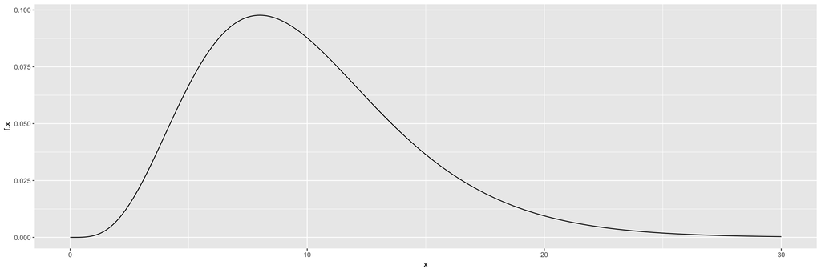

Density function of a chi-square random variable with 10 degrees of freedom

## Confidence Intervals

A confidence interval is a set of points defined by a lower bound and an upper bound that are theoretically expected to contain a parameter of interest $(1-\alpha)\times 100 \%$ of the time when the experiment is repeated. The theory behind confidence intervals is valid only when the data are collected according to the models assumed. The general form of a confidence interval is

$$point \ estimate \ \pm \ (critical \ value)(standard \ error)$$

From the theorems above, this general form for a confidence interval can be adapted to specific situations.